# Analysis Replication Assignment

### Loading the Required Packages

```r
library(readr)
library(ggplot2)
library(dplyr)
library(shiny)
library(tidyverse)
library(curl)
```

# Introduction

The published article, “Seed fates of four rainforest tree species in the fragmented forests of Anamalais in the southern Western Ghats, India” by Abhishek Gopala, Divya Mudappa, TR Shankar Raman, Rohit Naniwadekar publishes data on the seed fates of four different tree species in fragmented forests in India. The tree species include: Canarium strictum, Heynea trijuga, Myristica dactyloides, and Persea macrantha. In the article, it describes how seed predation is key in controlling plant population and the structure within forests. Forest fragmentation and habitat loss is directly correlated with seed predation and altered tree recruitment. This article examines four different rainforest tree species and the influence of forest type: benchmark N=3, fragmented N=5, and seed size on the proportion of seeds: 1) predated by vertebrate seed predators, 2) predated by invertebrate seed predators, and 3) removed by vertebrate seed predators. The seeds were tracked by putting seeds in four 1x1 meter plots under each canopy type. Camera traps were placed under a subset of trees N=29 and there was a total of N=712 trap nights. Nine species of seed predators was recorded and it is noted that they differed between tree species. This study brings forth the idea that seed predation can alter regeneration patterns and alter adult tree communities in fragmented forests.

# Replicating a Figure

### The Figure Being Replicated

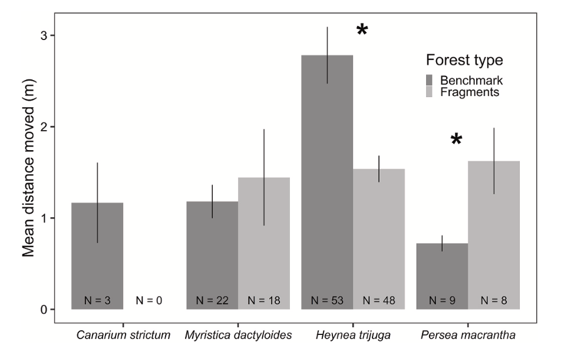

### Curling in the Data

```r
f <- curl("https://raw.githubusercontent.com/lilliansoccer10/holdenl-data-replication-assignment/main/Distance_moved.csv")
my_data <- read.csv(f, header = TRUE, sep = ",", stringsAsFactors = FALSE)
head(my_data)
```

```
##                 Tree_sp Tree_id Distance_moved_m Forest_type
## 1     Canarium strictum  CAST07              0.5   Benchmark
## 2     Canarium strictum  CAST07              2.0   Benchmark
## 3 Myristica dactyloides  MYDA03              2.0   Benchmark
## 4 Myristica dactyloides  MYDA03              0.5   Benchmark
## 5 Myristica dactyloides  MYDA03              1.0   Benchmark
## 6 Myristica dactyloides  MYDA03              1.0   Benchmark
```

### Organizing The Data Set with Piping

```r
#Add Columns that Expresses Mean, Standard Deviation, Standard Error, Upper Limit, and Lower Limit and Organizes it by Tree Species and Forest Type
new_data <- my_data %>%
  group_by(Tree_sp, Forest_type) %>%
  summarize(Distance_moved_means=mean(Distance_moved_m), sd_Distance_moved=sd(Distance_moved_m),
            N_N=n(),
            se=sd_Distance_moved/sqrt(N_N),
            upper_limit=Distance_moved_means+se,
            lower_limit=Distance_moved_means-se
  )
head(new_data)
```

```
## # A tibble: 6 × 8
## # Groups:   Tree_sp [4]
##   Tree_sp        Forest_type Distance_moved_means sd_Distance_moved   N_N     se
##   <chr>          <chr>                      <dbl>             <dbl> <int>  <dbl>
## 1 Canarium stri… Benchmark                  1.17              0.764     3 0.441
## 2 Heynea trijuga Benchmark                  2.78              2.27     53 0.311
## 3 Heynea trijuga Fragments                  1.54              1.01     48 0.146
## 4 Myristica dac… Benchmark                  1.18              0.853    22 0.182
## 5 Myristica dac… Fragments                  1.44              2.24     18 0.528
## 6 Persea macran… Benchmark                  0.722             0.264     9 0.0878
## # ℹ 2 more variables: upper_limit <dbl>, lower_limit <dbl>
```

### Plotting the Data

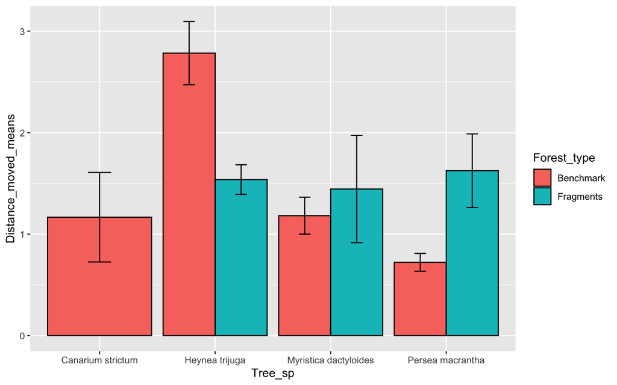

```r
g <- ggplot() +
geom_col(data = new_data, mapping = aes(x = Tree_sp, y = Distance_moved_means, group=Forest_type, fill = Forest_type), colour = "black", position = "dodge") +
geom_errorbar(data = new_data, aes(x=Tree_sp, ymin = lower_limit, ymax = upper_limit, fill= Forest_type), width=.2, position=position_dodge(.9))
g
```

# Replicating A Descriptive Statistical Analysis

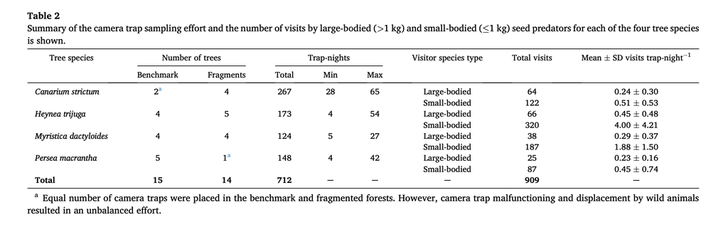

### Curling in the Data

```r
f <- curl("https://raw.githubusercontent.com/lilliansoccer10/holdenl-data-replication-assignment/main/Visits_seedpredators_CT.csv")
data <- read.csv(f, header = TRUE, sep = ",", stringsAsFactors = FALSE)
head(data)
```

```
##             Tree_sp Tree_id Forest_type CT_trap_nights  Visitor_sp_common_name
## 1 Canarium strictum  CAST03   Benchmark             35 Jungle striped squirrel
## 2 Canarium strictum  CAST03   Benchmark             35               Murid sp1
## 3 Canarium strictum  CAST03   Benchmark             35 Sahyadris forest\xa0rat
## 4 Canarium strictum  CAST04   Fragments             40          Indian muntjac
## 5 Canarium strictum  CAST04   Fragments             40 Jungle striped squirrel
## 6 Canarium strictum  CAST04   Fragments             40  Malabar spiny dormouse
##   Visitor_sp_scientific_name Body_size Num_visits
## 1     Funambulus tristriatus     Small          4
## 2                  Murid sp1     Small          1
## 3             Rattus satarae     Small          6
## 4          Muntiacus muntjak     Large          8
## 5     Funambulus tristriatus     Small         18
## 6    Platacanthomys lasiurus     Small          1
```

### Organizing The Data Set with Piping

Because each column of data is organized differently, information will need to be extracted individually:

#### Piping to Find the Total Number of Benchmark and Fragment Trees that Contain Camera Traps Per Tree Species

```r
dataIII <-
  data %>%
  group_by(Tree_sp, Forest_type) %>%
  summarize(Number_of_trees = n_distinct(Tree_id))
dataIII
```

```
## # A tibble: 8 × 3
## # Groups:   Tree_sp [4]
##   Tree_sp               Forest_type Number_of_trees
##   <chr>                 <chr>                 <int>
## 1 Canarium strictum     Benchmark                 2
## 2 Canarium strictum     Fragments                 4
## 3 Heynea trijuga        Benchmark                 4
## 4 Heynea trijuga        Fragments                 5
## 5 Myristica dactyloides Benchmark                 4
## 6 Myristica dactyloides Fragments                 4
## 7 Persea macrantha      Benchmark                 5
## 8 Persea macrantha      Fragments                 1
```

#### Piping to Find the Maximum Number of Trap Nights per Tree Species

```r
dataIIII <-
  data %>%
  group_by(Tree_sp) %>%
  summarize(Max = max(CT_trap_nights, na.rm=TRUE))
dataIIII
```

```
## # A tibble: 4 × 2
##   Tree_sp                 Max
##   <chr>                 <int>
## 1 Canarium strictum        65
## 2 Heynea trijuga           54
## 3 Myristica dactyloides    27
## 4 Persea macrantha         42
```

#### Piping to Find the Minimum Number of Trap Nights per Tree Species

```r
dataV <-
  data %>%
  group_by(Tree_sp) %>%
  summarize(Min = min(CT_trap_nights, na.rm=TRUE))
dataV
```

```
## # A tibble: 4 × 2
##   Tree_sp                 Min
##   <chr>                 <int>
## 1 Canarium strictum        28
## 2 Heynea trijuga            4
## 3 Myristica dactyloides     5
## 4 Persea macrantha          4
```

#### Piping to Find the Total Visits for Large (>1 kg) and Small Bodied (<1kg) Seed Predator Visits per Tree Species

```r
dataVI <-
  data %>%
  group_by(Tree_sp, Body_size) %>%
  summarize(Total_visits=sum(Num_visits))
dataVI
```

```
## # A tibble: 8 × 3
## # Groups:   Tree_sp [4]
##   Tree_sp               Body_size Total_visits
##   <chr>                 <chr>            <int>
## 1 Canarium strictum     Large               64
## 2 Canarium strictum     Small              122
## 3 Heynea trijuga        Large               66
## 4 Heynea trijuga        Small              320
## 5 Myristica dactyloides Large               38
## 6 Myristica dactyloides Small              187
## 7 Persea macrantha      Large               25
## 8 Persea macrantha      Small               87
```

#### Piping to Find the Total Trap Nights per Tree Species

```r
dataVII <-
  data %>%
  group_by(Tree_sp) %>%
  summarize(Total=sum(unique(CT_trap_nights)))
dataVII
```

```
## # A tibble: 4 × 2
##   Tree_sp               Total
##   <chr>                 <int>
## 1 Canarium strictum       267
## 2 Heynea trijuga          159
## 3 Myristica dactyloides    91
## 4 Persea macrantha        148
```

Canarium and Persea match what was presented in the paper, but Heynea and Myristica do not, for some reason.

#### Merging Data to Find the Mean Visits per Trap Night

```r
dataVIII <- merge(dataVI, dataVII) #merge the data sets with total trap nights and total visits
dataVIII
```

```
##                 Tree_sp Body_size Total_visits Total
## 1     Canarium strictum     Large           64   267
## 2     Canarium strictum     Small          122   267
## 3        Heynea trijuga     Large           66   159
## 4        Heynea trijuga     Small          320   159
## 5 Myristica dactyloides     Large           38    91
## 6 Myristica dactyloides     Small          187    91
## 7      Persea macrantha     Large           25   148
## 8      Persea macrantha     Small           87   148
```

#### Piping to Find the Mean Visits per Trap Night

```r
dataVIIII <-
  dataVIII %>%
  group_by(Tree_sp, Body_size) %>%
  summarize(Mean=Total_visits/Total)
dataVIIII
```

```
## # A tibble: 8 × 3
## # Groups:   Tree_sp [4]
##   Tree_sp               Body_size  Mean
##   <chr>                 <chr>     <dbl>
## 1 Canarium strictum     Large     0.240
## 2 Canarium strictum     Small     0.457
## 3 Heynea trijuga        Large     0.415
## 4 Heynea trijuga        Small     2.01
## 5 Myristica dactyloides Large     0.418
## 6 Myristica dactyloides Small     2.05
## 7 Persea macrantha      Large     0.169
## 8 Persea macrantha      Small     0.588
```

# Replicating a GLMM

```r
library(lme4) #load the lme4 package to use the glmer() function
```

### Results of the GLMM Being Replicated

A GLMM with a poisson error structure examining the influence of forest type on the visitations of seed predators with tree species as a random variable was run using the offset() function to account for variable trap nights.

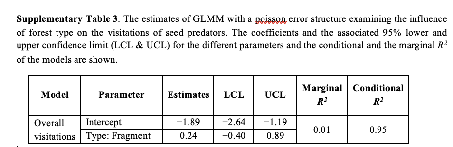

#### Piping to Determine the Number of Visits Based Tree Species and Forest Type

```r
glmmdata <-
data %>%
  group_by(Tree_sp, Forest_type) %>%
  reframe(Num_visits)
glmmdata
```

```
## # A tibble: 99 × 3
##    Tree_sp           Forest_type Num_visits
##    <chr>             <chr>            <int>
##  1 Canarium strictum Benchmark            4
##  2 Canarium strictum Benchmark            1
##  3 Canarium strictum Benchmark            6
##  4 Canarium strictum Benchmark            2
##  5 Canarium strictum Benchmark            2
##  6 Canarium strictum Fragments            8
##  7 Canarium strictum Fragments           18
##  8 Canarium strictum Fragments            1
##  9 Canarium strictum Fragments            5
## 10 Canarium strictum Fragments           15
## # ℹ 89 more rows
```

#### In order to get the offset() function to work properly, I had to turn CT_trap_nights into a separate vector:

```r
Trap_nights <- data$CT_trap_nights
Trap_nights
```

```
##  [1] 35 35 35 40 40 40 40 40 37 37 37 28 28 65 65 65 65 65 62 62 62 62 62  6  6
## [26] 20 20 20 20 20 20  5  5  9  9  9  9  9  9  9  9 27 27 24 24 24 24 24 24 24
## [51] 24 24 24 16 16 16 42 42 42 42 23 23 31 31 31 32 32 32  4  4  4  4  4  9  9
## [76]  9 18 18 18 18 18 34 33 33 33 33  7  7  7  7  7 54 54 54 54 54 54  7  7
```

### Replicating the GLMM

```r
glmmI <- glmer(Num_visits~Forest_type + offset(log(Trap_nights)) + (1|Tree_sp), data=glmmdata, family = poisson(link = "log"))
summary(glmmI)
```

```
## Generalized linear mixed model fit by maximum likelihood (Laplace
##   Approximation) [glmerMod]
##  Family: poisson  ( log )
## Formula: Num_visits ~ Forest_type + offset(log(Trap_nights)) + (1 | Tree_sp)
##    Data: glmmdata
##
##      AIC      BIC   logLik deviance df.resid
##   2063.1   2070.8  -1028.5   2057.1       96
##
## Scaled residuals:
##    Min     1Q Median     3Q    Max
## -4.444 -2.642 -1.386  1.294 24.878
##
## Random effects:
##  Groups  Name        Variance Std.Dev.
##  Tree_sp (Intercept) 0.3786   0.6153
## Number of obs: 99, groups:  Tree_sp, 4
##
## Fixed effects:
##                      Estimate Std. Error z value Pr(>|z|)
## (Intercept)          -1.26430    0.31241  -4.047 5.19e-05 ***
## Forest_typeFragments  0.23865    0.07549   3.161  0.00157 **
## ---
## Signif. codes:  0 '***' 0.001 '**' 0.01 '*' 0.05 '.' 0.1 ' ' 1
##
## Correlation of Fixed Effects:
##             (Intr)
## Frst_typFrg -0.129
```

#### Determine the Marginal and Conditional R2 for the GLMM

```r
#install.packages("performance")
library(performance)
r2_nakagawa(glmmI) #use r2_nakagawa package to find the marginal and conditional R2 values
```

```
## # R2 for Mixed Models
##
##   Conditional R2: 0.217
##      Marginal R2: 0.008
```

The marginal R2 for the mixed model is the same as published in the paper, however the conditional is not for some reason.

#### Determine the Confidence Intervals for the GLMM

```r
confint(glmmI) #use confint to find the confidence intervals of the glmm
```

```
## Computing profile confidence intervals ...
```

```
##                            2.5 %     97.5 %
## .sig01                0.34623190  1.5156586
## (Intercept)          -2.05438590 -0.4772319
## Forest_typeFragments  0.09108537  0.3873828
```

#### References

https://www.sciencedirect.com/science/article/pii/S1146609X20301909  
https://www.stat.umn.edu/geyer/5931/mle/seed2.pdf  
https://fuzzyatelin.github.io/bioanth-stats/modules.html  
https://stackoverflow.com/questions/13050516/how-to-make-dodge-in-geom-bar-agree-with-dodge-in-geom-errorbar-geom-point